# lab9

Patryk Tokarski

2022-05-09

```r
data <- read.csv('data/gapminder-FiveYearData.csv')
library(tidyverse)
summary(data)
```

```
##    country               year           pop             continent
##  Length:1704        Min.   :1952   Min.   :6.001e+04   Length:1704
##  Class :character   1st Qu.:1966   1st Qu.:2.794e+06   Class :character
##  Mode  :character   Median :1980   Median :7.024e+06   Mode  :character
##                     Mean   :1980   Mean   :2.960e+07
##                     3rd Qu.:1993   3rd Qu.:1.959e+07
##                     Max.   :2007   Max.   :1.319e+09
##     lifeExp        gdpPercap
##  Min.   :23.60   Min.   :   241.2
##  1st Qu.:48.20   1st Qu.:  1202.1
##  Median :60.71   Median :  3531.8
##  Mean   :59.47   Mean   :  7215.3
##  3rd Qu.:70.85   3rd Qu.:  9325.5
##  Max.   :82.60   Max.   :113523.1
```

```r
data %>%
  filter(continent == 'Americas') %>%
  head()
```

```
##     country year      pop continent lifeExp gdpPercap
## 1 Argentina 1952 17876956  Americas  62.485  5911.315
## 2 Argentina 1957 19610538  Americas  64.399  6856.856
## 3 Argentina 1962 21283783  Americas  65.142  7133.166
## 4 Argentina 1967 22934225  Americas  65.634  8052.953
## 5 Argentina 1972 24779799  Americas  67.065  9443.039
## 6 Argentina 1977 26983828  Americas  68.481 10079.027
```

### Do ramki danych gapminder dodaj zmienną gdp zdefiniowaną jako iloczyn wielkości populacji oraz PKB na osobę (gdp per person).

```r
data %>%
  mutate(gdp = pop * gdpPercap) %>%
  head()
```

```
##       country year      pop continent lifeExp gdpPercap         gdp
## 1 Afghanistan 1952  8425333      Asia  28.801  779.4453  6567086330
## 2 Afghanistan 1957  9240934      Asia  30.332  820.8530  7585448670
## 3 Afghanistan 1962 10267083      Asia  31.997  853.1007  8758855797
## 4 Afghanistan 1967 11537966      Asia  34.020  836.1971  9648014150
## 5 Afghanistan 1972 13079460      Asia  36.088  739.9811  9678553274
## 6 Afghanistan 1977 14880372      Asia  38.438  786.1134 11697659231
```

### Zidentyfikuj obserwację (kraj oraz rok w którym się to wydarzyło) o najniższym PKB na osobę.

```r
data %>%
  filter(gdpPercap == min(gdpPercap)) %>%
  select(country, year)
```

```
##           country year
## 1 Congo Dem. Rep. 2002
```

### Zidentyfikuj obserwacje z przeciętną długością życia powyżej średniej dla każdego z kontynentów. Rozgrupuj dane

```r
data4 <- data %>%
  group_by(continent) %>%
  filter(lifeExp > mean(lifeExp)) %>%
  ungroup()
```

```r
data %>% group_by(continent) %>% summarise(mean(lifeExp))
```

```
## # A tibble: 5 x 2
##   continent `mean(lifeExp)`
##   <chr>               <dbl>
## 1 Africa               48.9
## 2 Americas             64.7
## 3 Asia                 60.1
## 4 Europe               71.9
## 5 Oceania              74.3
```

### Policz liczbę obserwacji znalezionych w poprzednim przykładzie dla każdego z kontynentów.

```r
data4 %>%
  group_by(continent) %>%
  summarise(n())
```

```
## # A tibble: 5 x 2
##   continent `n()`
##   <chr>     <int>
## 1 Africa      282
## 2 Americas    176
## 3 Asia        216
## 4 Europe      189
## 5 Oceania      10
```

### Oblicz średnią ze średnich długości życia (grand_mean) oraz sumaryczne PKB (total_gdp) ze wszystkich obserwacji.

```r
data %>%
  summarise(grand_mean = mean(lifeExp), total_gdp=sum(gdpPercap*pop))
```

```
##   grand_mean    total_gdp
## 1   59.47444 3.183235e+14
```

### Stwórz te same statystyki w każdym z wymienionych w tabeli lat.

```r
data %>%
  group_by(year) %>%
  summarise(grand_mean = mean(lifeExp), total_gdp=sum(gdpPercap*pop))
```

```
## # A tibble: 12 x 3
##     year grand_mean total_gdp
##    <int>      <dbl>     <dbl>
##  1  1952       49.1   7.04e12
##  2  1957       51.5   8.90e12
##  3  1962       53.6   1.10e13
##  4  1967       55.7   1.42e13
##  5  1972       57.6   1.84e13
##  6  1977       59.6   2.23e13
##  7  1982       61.5   2.54e13
##  8  1987       63.2   3.01e13
##  9  1992       64.2   3.45e13
## 10  1997       65.0   4.10e13
## 11  2002       65.7   4.73e13
## 12  2007       67.0   5.81e13
```

### Stwórz wykres rozrzutu pokazujący zależność pomiędzy PKB na osobę (oś x), a oczekiwaną długością życia (oś y) w 2007 roku.

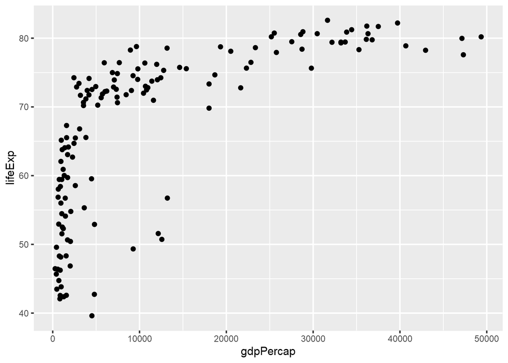

```r
data8 <-data %>%
  filter(year == 2007)

plot8 <- ggplot(data8, aes(x = gdpPercap, y = lifeExp))+
  geom_point()

plot8
```

### Na poprzednim wykresie dodaj linię regresji rysowaną metodą loess bez wyrysowanego przedziału ufności.

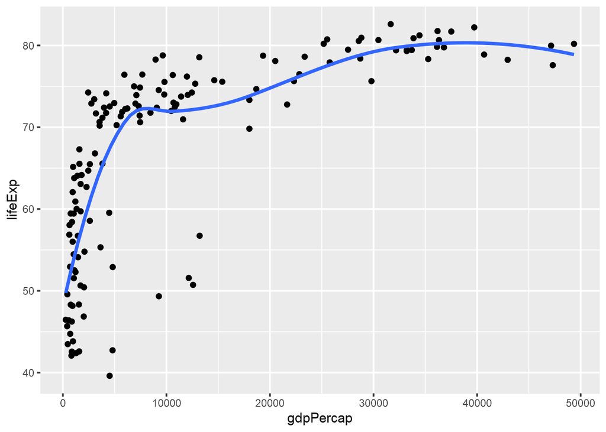

```r
plot8+
  geom_smooth(se = F, method = loess)
```

### Na wykresie z przykładu 8 dodaj linię regresji liniowej bez wyrysowanego przedziału ufności.

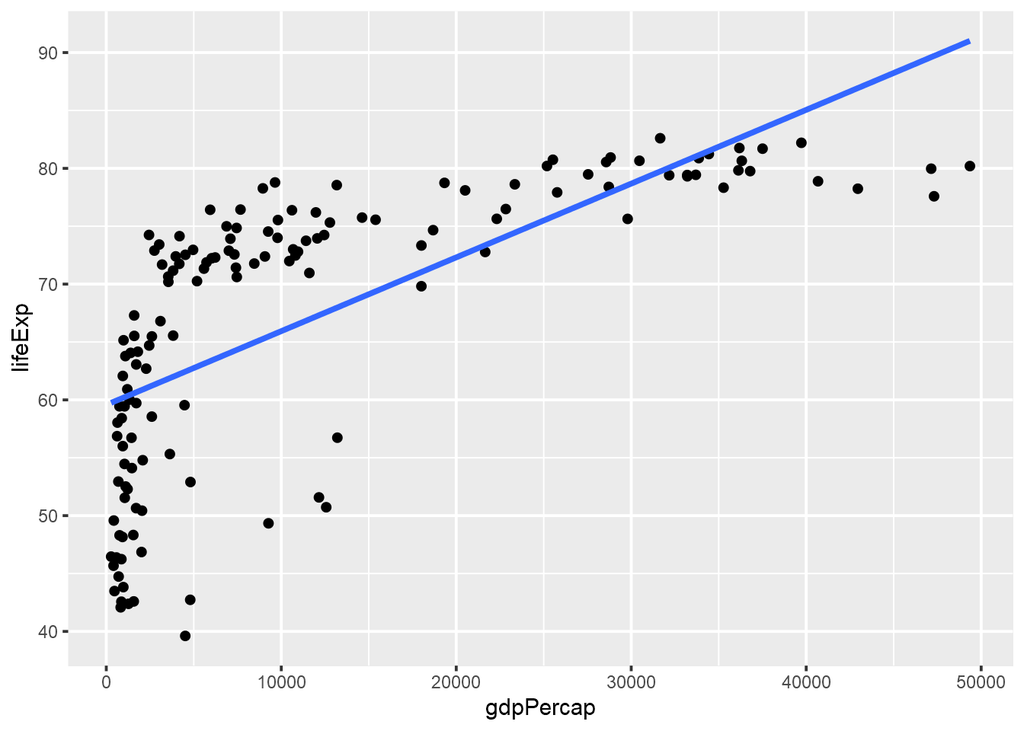

```r
plot8+
  geom_smooth(se = F, method = lm)
```

### Stwórzcie wykres rozrzutu pokazujący rok na osi x oraz oczekiwaną średnią długością życia w danym roku na osi y. Punkty połącz linią

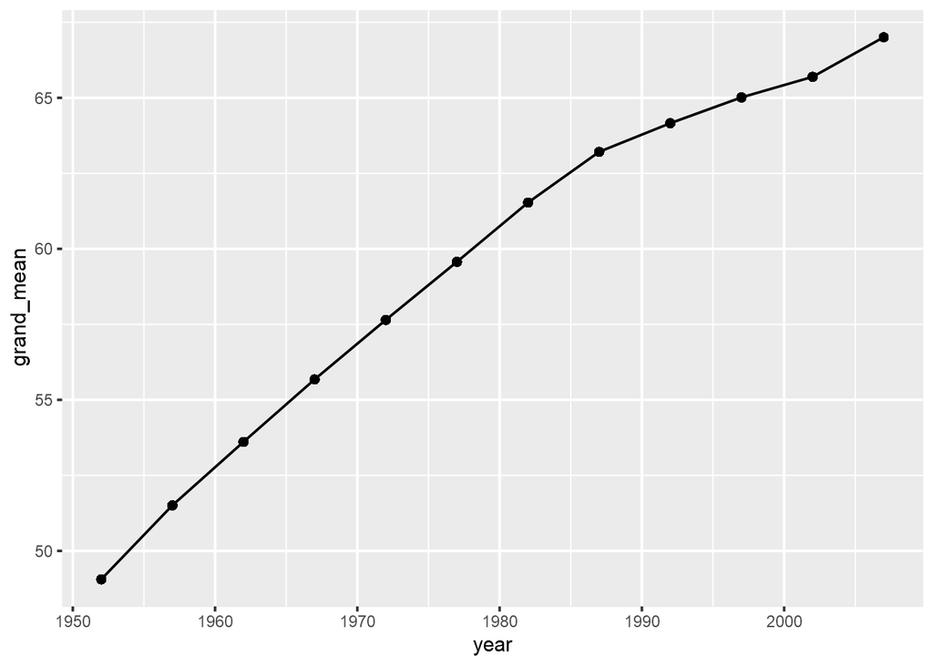

```r
data11 <- data %>%
  group_by(year) %>%
  mutate(grand_mean = mean(lifeExp)) %>%
  ungroup()

ggplot(data11, aes(x = year, y = grand_mean))+
  geom_point()+
  geom_line()
```

### Zmodyfikuj poprzedni wykres tak, aby pokazane zostały linie dla każdego z kontynentów (inny kolor dla każdego kontynentu + legenda)

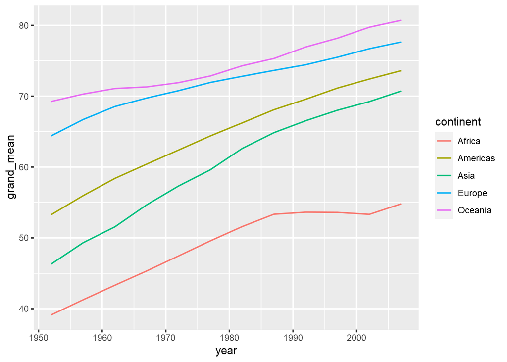

```r
data12 <- data %>%
  group_by(year,continent) %>%
  mutate(grand_mean = mean(lifeExp))

ggplot(data12)+
  geom_line(aes(x = year,y=grand_mean, color=continent))
```

### Modyfikuj wykres z zadania 8, tak aby kolory punktów odpowiadały kontynentom (+legenda)

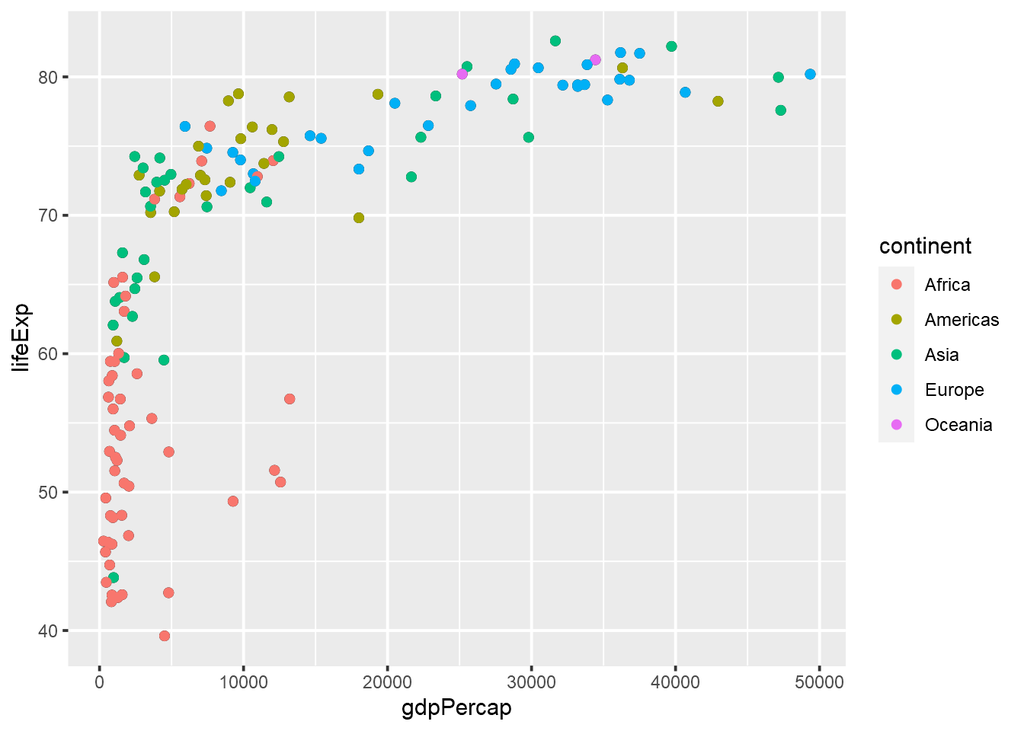

```r
plot13 <- plot8+
  geom_point(aes(color = continent,),)

plot13
```

### Modyfikuj poprzedni wykres tak, aby wielkość punktów odpowiadała wielkości populacji (pop).

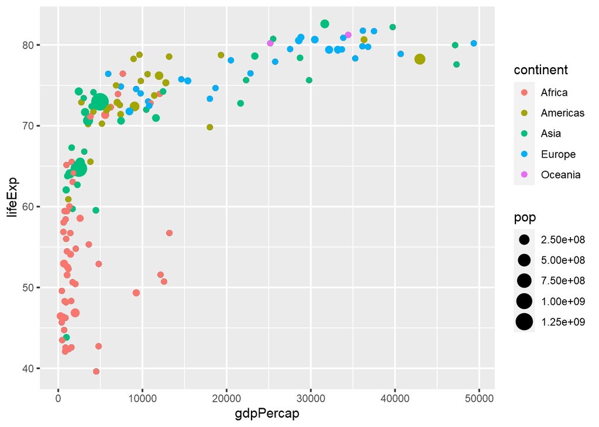

```r
plot13+
  geom_point(aes(color = continent, size = pop))
```